# ESM 244: Lizards Model

Kristina Fauss

2022-02-21

```r
knitr::opts_chunk$set(echo = TRUE,message=FALSE,warning = FALSE)
library(tidyverse)
library(Metrics)
library(cowplot)
library(knitr)
library(sjPlot)
```

## Overview

### Data:

Title: Lizard pitfall trap data from 11 NPP study locations at the Jornada Basin LTER site, 1989-2006.

Description: The time period captured is 1989 to 2006. The data includes the following contents as information about lizards captured at the Jornada Basin LTER across 11 study locations: [date, zone, site, plot, pit, spp, sex, rcap, toe_num, SV_length, weight, tail, pc].

Site, plot, and pit refer to capture location, while zone refers to vegetation. Spp indicates a species code. Rcap indicates whether the lizard is a recapture. Sex, toe_num, SV_length, total_length, weight, and tail all reference characteristics of the lizard. Data is intended to track how desertification (change in vegetation) in the Chihuahuan desert affects consumer species.

Citation: *Lightfoot, D. and W.G. Whitford. 2020. Lizard pitfall trap data from 11 NPP study locations at the Jornada Basin LTER site, 1989-2006 ver 37. Environmental Data Initiative. https://doi.org/10.6073/pasta/4a6e258fb49c31e222ecbbcfd128967f (Accessed 2022-02-03).*

```r
# Read in cleaned data:
liz_data <- read.csv('lizard.csv')
```

### Questions:

Apply non least squares regression to estimate model parameters for a lizard length to weight model.

### Data Exploration

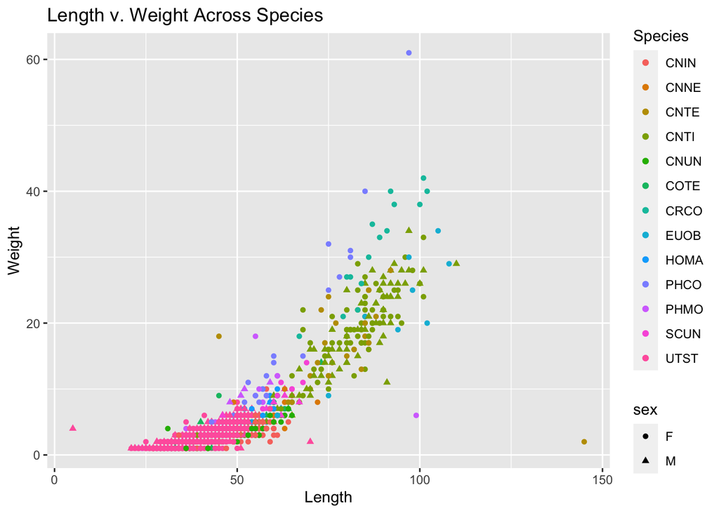

```r
ggplot(data=liz_data, aes(x=SV_length, y=weight))+
  labs(title='Length v. Weight Across Species',x='Length',y='Weight',color='Species')+
  geom_point(aes(color=spp,shape=sex))
```

### Fit a Snout Length to Weight Model

Original Model:
$$W = a(SVL)^b$$

Log transform:
$$ln(W) = b*ln(SVL) + ln(a)$$

```r
# Calculate log of SVL and Weight
liz_data$log_weight <- log(liz_data$weight)
liz_data$log_SV_length <- log(liz_data$SV_length)
```

OLS Model of Log-Transformed Data: Supply coeficients to NLS Model

```r
OLSmod_liz <- lm(log_weight ~ log_SV_length, data=liz_data)

# Get coefficients
coefs_liz <- as.data.frame(coef(OLSmod_liz))
b = coefs_liz$`coef(OLSmod_liz)`[2]
log_a = coefs_liz$`coef(OLSmod_liz)`[1]
a = exp(log_a)
```

Define original function:

```r
f_liz<-function(coef_a,coef_b,SV_length){
  out=coef_a*(SV_length^coef_b)
  return(out)
}
```

NLS model:

```r
# Guess carrying capacity as the largest val in our data
guess_vec=c(a,b)

NLSmod_liz=nls(weight~f_liz(coef_a,coef_b,SV_length),
                  data=liz_data,
                  start=list(coef_a=guess_vec[1],coef_b=guess_vec[2]),
                  trace=TRUE) # reached a convergence quickly?
```

```
## 17064.55    (3.24e-01): par = (0.0002085246 2.537119)
## 16502.11    (2.59e-01): par = (0.0002772028 2.477012)
## 15516.47    (5.68e-02): par = (0.0003473554 2.443989)
## 15466.89    (2.62e-03): par = (0.000337407 2.45569)
## 15466.81    (6.77e-04): par = (0.000342001 2.452585)
## 15466.80    (1.56e-04): par = (0.0003409034 2.453348)
## 15466.80    (3.81e-05): par = (0.0003411808 2.453161)
## 15466.80    (9.33e-06): par = (0.0003411133 2.453207)
```

```r
tab_model(NLSmod_liz)
```

|  | weight |  |  |
| --- | --- | --- | --- |
| Predictors | Estimates | CI | p |
| coef a | 0.00 | 0.00 – 0.00 | **<0.001** |
| coef b | 2.45 | 2.40 – 2.51 | **<0.001** |
| Observations | 1986 |  |  |
| R<sup>2</sup> | 0.781 |  |  |

Plot the NLS model and data:

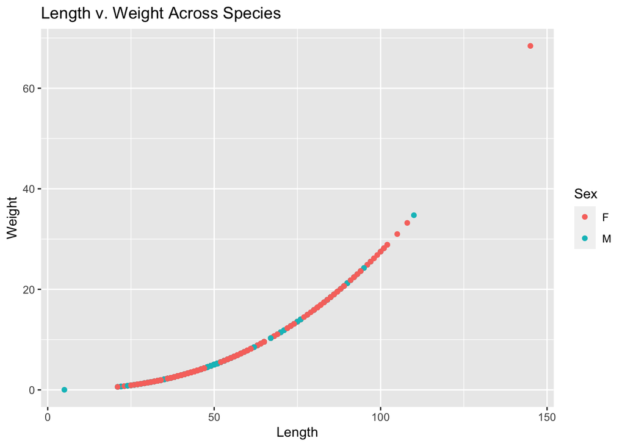

```r
# Predict data from NLS model:
liz_data$weight_pred<-predict(NLSmod_liz)

# Plot
ggplot()+
  geom_point(data=liz_data, aes(x=SV_length, y=weight_pred, color=sex))+
  labs(title='Length v. Weight Across Species',x='Length',y='Weight',color='Sex')
```

### Western Whiptail Lizard Model:

```r
# Filter out Western Whiptail Lizard Data: CNTI
cnti_data <- filter(liz_data,spp=='CNTI',sex=='M')
```

Data Exploration, CNTI

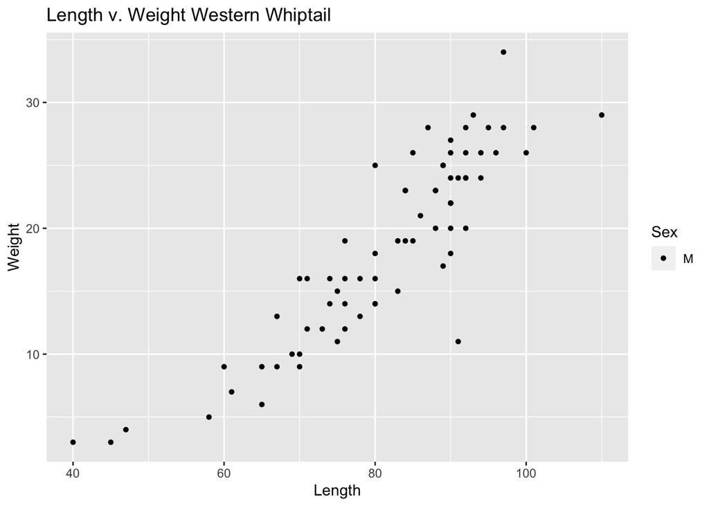

```r
ggplot(data=cnti_data, aes(x=SV_length, y=weight))+
  labs(title='Length v. Weight Western Whiptail',x='Length',y='Weight',shape='Sex')+
  geom_point(aes(shape=sex))
```

### Fit the Snout Length to Weight Model on CNTI

```r
# Calculate log of SVL and Weight
cnti_data$log_weight <- log(cnti_data$weight)
cnti_data$log_SV_length <- log(cnti_data$SV_length)
```

OLS Model of Log-Transformed Data: Supply coeficients to NLS Model

```r
OLSmod_cnti <- lm(log_weight ~ log_SV_length, data=cnti_data)

# Get coefficients
coefs_cnti <- as.data.frame(coef(OLSmod_cnti))
b_cnti = coefs_cnti$`coef(OLSmod_cnti)`[2]
log_a_cnti = coefs_cnti$`coef(OLSmod_cnti)`[1]
a_cnti = exp(log_a_cnti)
```

Define original function:

```r
f_cnti<-function(coef_a,coef_b,SV_length){
  out=coef_a*(SV_length^coef_b)
  return(out)
}
```

NLS model:

```r
# Guess carrying capacity as the largest val in our data
guess_vec_cnti=c(a_cnti,b_cnti)

NLSmod_cnti=nls(weight~f_cnti(coef_a,coef_b,SV_length),
                  data=cnti_data,
                  start=list(coef_a=guess_vec_cnti[1],coef_b=guess_vec_cnti[2]),
                  trace=TRUE) # reached a convergence quickly?
```

```
## 849.1572    (2.38e-01): par = (0.0001204877 2.698108)
## 845.6613    (2.27e-01): par = (0.0001330208 2.674996)
## 843.4176    (2.19e-01): par = (0.000145976 2.653427)
## 841.8629    (2.14e-01): par = (0.0001592699 2.633319)
## 840.6339    (2.09e-01): par = (0.0001728179 2.614592)
## 839.5079    (2.05e-01): par = (0.0001865362 2.597165)
## 838.3596    (2.00e-01): par = (0.0002003434 2.580958)
## 837.1280    (1.96e-01): par = (0.0002141623 2.565892)
## 835.7939    (1.91e-01): par = (0.0002279206 2.551894)
## 834.3628    (1.85e-01): par = (0.0002415522 2.538892)
## 832.8544    (1.80e-01): par = (0.0002549974 2.526816)
## 831.2942    (1.74e-01): par = (0.0002682034 2.515604)
## 830.9229    (1.72e-01): par = (0.0002940453 2.494784)
## 829.4806    (1.66e-01): par = (0.0003185494 2.476905)
## 827.3386    (1.57e-01): par = (0.0003414678 2.461569)
## 826.9172    (1.55e-01): par = (0.0003838388 2.435273)
## 822.7939    (1.37e-01): par = (0.0004187718 2.416406)
## 818.0645    (1.14e-01): par = (0.0004743039 2.389404)
## 809.0350    (4.10e-02): par = (0.0005336902 2.365838)
## 807.6757    (1.94e-04): par = (0.0005309859 2.368548)
## 807.6756    (1.74e-05): par = (0.0005316264 2.368276)
## 807.6756    (1.56e-06): par = (0.0005315662 2.368301)
```

```r
tab_model(NLSmod_cnti)
```

|  | weight |  |  |
| --- | --- | --- | --- |
| Predictors | Estimates | CI | p |
| coef a | 0.00 | -0.00 – 0.00 | 0.219 |
| coef b | 2.37 | 2.01 – 2.73 | **<0.001** |
| Observations | 72 |  |  |
| R<sup>2</sup> | 0.790 |  |  |

Plot the NLS model and data:

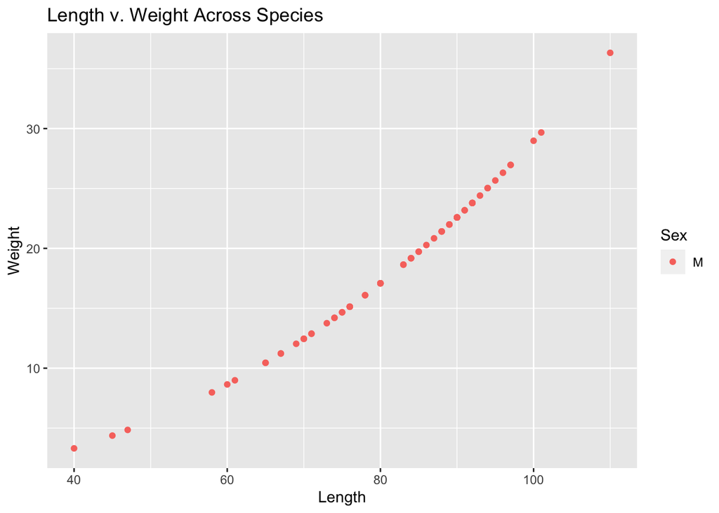

```r
# Predict data from NLS model:
cnti_data$weight_pred<-predict(NLSmod_cnti)

# Plot
ggplot()+
  geom_point(data=cnti_data, aes(x=SV_length, y=weight_pred, color=sex))+
  labs(title='Length v. Weight Across Species',x='Length',y='Weight',color='Sex')
```

### Plot of both models:

```r
# Filter model output trained on total to just CNTI for comparison:
liz_data_cnti<-filter(liz_data,spp=='CNTI',sex=='M')

# Calculate RMSE's
tot_mod_rmse <- rmse(liz_data_cnti$weight,liz_data_cnti$weight_pred)
cnti_mod_rmse <- rmse(cnti_data$weight,cnti_data$weight_pred)

cap=paste('RMSE for Total model over CNTI:',round(tot_mod_rmse,2),'\nRMSE for CNTI model over CNTI:',round(cnti_mod_rmse,2),'\nThe Male-CNTI specific model is better at predicting weights of Male CNTI lizards \nand should be used for this specific case but may not generalize well to other species.')
```

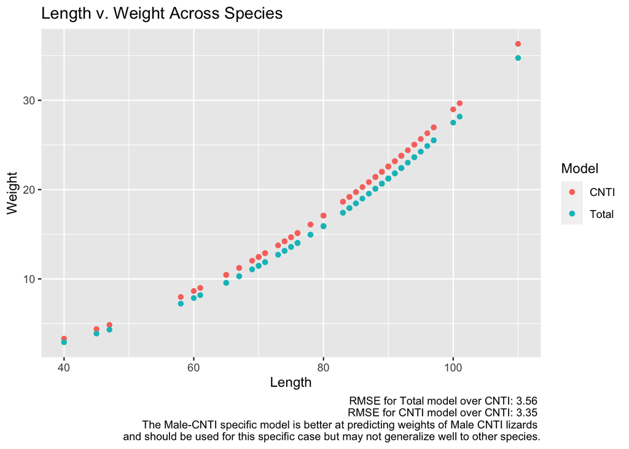

```r
# Plot
ggplot()+
  geom_point(data=cnti_data, aes(x=SV_length, y=weight_pred, col='CNTI'))+
  geom_point(data=liz_data_cnti, aes(x=SV_length, y=weight_pred, col='Total'))+
  labs(title='Length v. Weight Across Species',x='Length',y='Weight',color='Model',caption=cap)
```